# Confidence intervals and p-values

2022-10-04

## Confidence intervals

- Confidence intervals are a very useful concept widely employed by data analysts.
- A version of these that are commonly seen come from the `ggplot` geometry `geom_smooth`. Here is an example using a temperature dataset available in R:

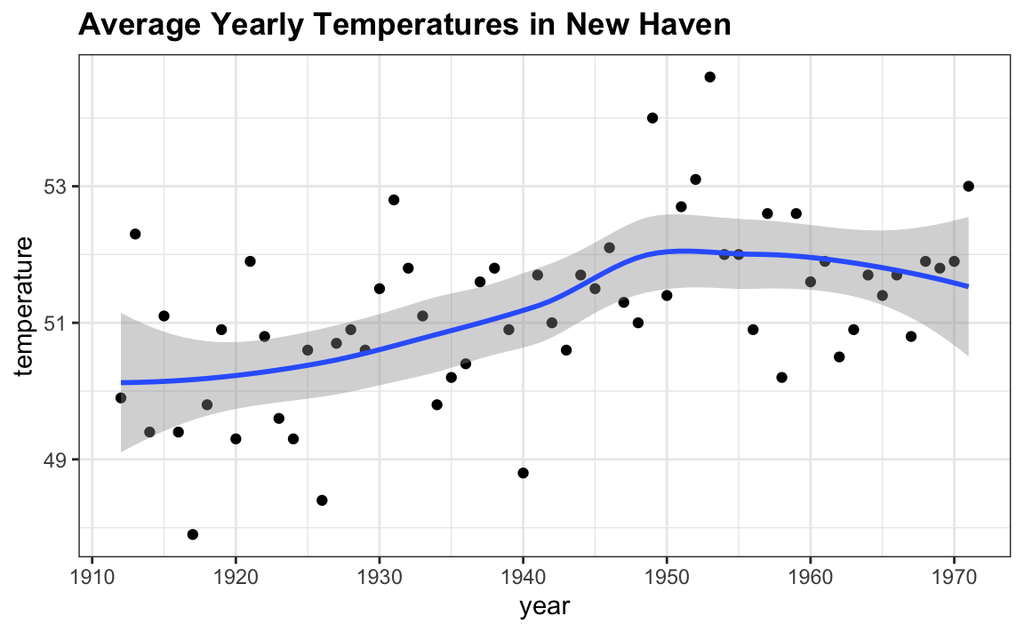

## Confidence intervals

- When we talk about Machine Learning, we will learn how the curve shown is obtained, but for now consider the shaded area around the curve.
- This is created using the concept of confidence intervals.

## Confidence intervals

- In our competition, you were asked to give an interval.
- One way to pass to the second round is to report a very large interval: e.g the interval \([0,1]\) is guaranteed to include \(p\).
- However, with an interval this big, we have no chance of winning the competition.
- Similarly, if you are an election forecaster and predict the spread will be between -100% and 100%, you will be ridiculed for stating the obvious.
- Even a smaller interval, such as saying the spread will be between -10% and 10%, will not be considered serious.

## Confidence intervals

- On the other hand, the smaller the interval we report, the smaller our chances are of winning the prize.
- Likewise, a bold pollster that reports very small intervals and misses the mark most of the time will not be considered a good pollster.
- Statistics helps us control where we fall in this spectrum.

## Confidence intervals

- We can use the statistical theory we have learned to compute the probability of any given interval including \(p\).
- If we are asked to create an interval with, say, a 95% chance of including \(p\), we can do that as well.
- These are called 95% confidence intervals.

## Confidence intervals

- When a pollster reports an estimate and a margin of error, they are, in a way, reporting a 95% confidence interval.
- Let’s show how this works mathematically.

## Confidence intervals

- What is the probability that \([\bar{X} - 2\hat{\mbox{SE}}(\bar{X}), \bar{X} + 2\hat{\mbox{SE}}(\bar{X})]\) contains the true proportion \(p\)?
- First, consider that the start and end of these intervals are random variables: every time we take a sample, they change.
- To illustrate this, let’s run a Monte Carlo simulation.

## Confidence intervals

- We use \(p=0.45\) as an example, but we can change it

```r
p <- 0.45
N <- 1000
```

- Run the following code over and over to see that the interval is random

```r
options(digits=2)
x <- sample(c(0, 1), size = N, replace = TRUE, prob = c(1-p, p))
x_hat <- mean(x)
se_hat <- sqrt(x_hat * (1 - x_hat) / N)
c(x_hat - 2 * se_hat, x_hat + 2 * se_hat)
```

```
#> [1] 0.42 0.49
```

## Reset digits

```r
options(digits=3)
```

## Confidence intervals

- To determine the probability that the interval includes \(p\), we need to compute this:

\[ \mbox{Pr}\left([ \bar{X} - 2\,\hat{\mbox{SE}}(\bar{X}), \bar{X} + 2\,\hat{\mbox{SE}}(\bar{X})] \mbox{ covers }p\right) \]

- We can write this as a mathematical formula:

\[ \mbox{Pr}\left( \bar{X} - 2\,\hat{\mbox{SE}}(\bar{X}) \leq p \leq \bar{X} + 2\,\hat{\mbox{SE}}(\bar{X}) \right) \]

## Confidence intervals

- By subtracting and dividing the same quantities in all parts of the equation, we get:

\[ \mbox{Pr}\left(-2 \leq \frac{\bar{X}- p}{\hat{\mbox{SE}}(\bar{X})} \leq 2\right) \]

- The term in the middle is an approximately normal random variable with expected value 0 and standard error 1.
- Let’s call it \(Z\) and rewrite it as:

\[ \mbox{Pr}\left(-2 \leq Z \leq 2\right) \]

## Confidence intervals

- We can compute \[\mbox{Pr}\left(-2 \leq Z \leq 2\right)\]

using

```r
pnorm(2) - pnorm(-2)
```

```
#> [1] 0.954
```

- so the probability is 95%.
- Technical note: to get exactly 95% we need to use 1.96 instead of 2.

## Confidence intervals

- If we want to have a larger probability, say 99%, we need to multiply by whatever `z` satisfies the following:

\[ \mbox{Pr}\left(-z \leq Z \leq z\right) = 0.99 \]

- Using:

```r
z <- qnorm(0.995)
z
```

```
#> [1] 2.58
```

- to confirm:

```r
pnorm(z) - pnorm(-z)
```

```
#> [1] 0.99
```

## Confidence intervals

- We can use this approach for any probability \(1-\alpha\): we set

`z = qnorm(1 - alpha/2)`

because

\[1 - \alpha/2 - \alpha/2 = 1-\alpha\]

## Confidence intervals

So, for example, for \(\alpha=0.05\), \(1 -\alpha/2 = 0.975\) and we get the 1.96 we have been using:

```r
qnorm(0.975)
```

```
#> [1] 1.96
```

## A Monte Carlo simulation

- We can run a Monte Carlo simulation to confirm that, in fact, a 95% confidence interval includes \(p\) 95% of the time.

```r
N <- 1000
B <- 10000
inside <- replicate(B, {
  x <- sample(c(0,1), size = N, replace = TRUE, prob = c(1-p, p))
  x_hat <- mean(x)
  se_hat <- sqrt(x_hat * (1 - x_hat) / N)
  between(p, x_hat - 1.96 * se_hat, x_hat + 1.96 * se_hat)
})
mean(inside)
```

```
#> [1] 0.948
```

## A Monte Carlo simulation

- The following plot shows the first 100 confidence intervals.

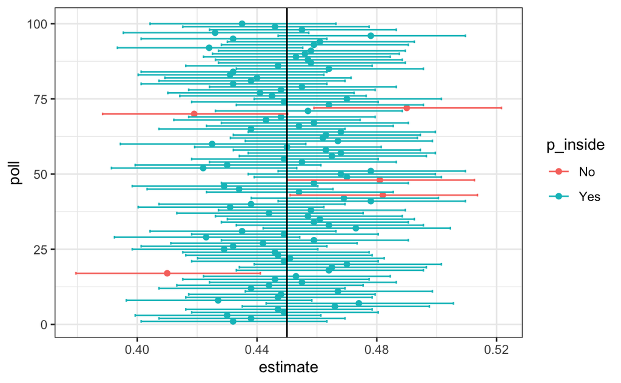

## The correct language

- When using the theory we described above, it is important to remember that it is the intervals that are random, not \(p\).
- In the plot above, we can see the random intervals moving around and \(p\), represented with the vertical line, staying in the same place.
- The proportion of blue in the urn \(p\) is not. So the 95% relates to the probability that this random interval falls on top of \(p\).
- With the setup we described, saying the \(p\) has a 95% chance of being between this and that is technically an incorrect statement because \(p\) is not random.

## Power

- Pollsters are not successful at providing correct confidence intervals, but rather at predicting who will win.
- When we took a 25 bead sample size, the confidence interval for p is:

```r
N <- 25
x_hat <- 0.48
x_hat  + c(-1.96, 1.96) * sqrt(x_hat * (1 - x_hat) / N)
```

```
#> [1] 0.284 0.676
```

- If this were a poll and we were forced to make a declaration, we would have to say it was a “toss-up”.

## Power

- A problem with our poll results is that given the sample size and the value of \(p\), we would have to sacrifice on the probability of an incorrect call to create an interval that does not include 0.
- This does not mean that the election is close.
- It only means that we have a small sample size.
- In statistical textbooks this is called lack of *power*. In the context of polls, *power* is the probability of detecting spreads different from 0.
- By increasing our sample size, we lower our standard error and therefore have a much better chance of detecting the direction of the spread.

## p-values

- Say we take a random sample of \(N=100\) and we observe \(52\) blue beads, which gives us \(\bar{X} = 0.52\).
- This seems to be pointing to the existence of more blue than red beads since 0.52 is larger than 0.5. However, as data scientists we need to be skeptical.
- We know there is chance involved in this process and we could get a 52 even when the actual spread is 0.
- We call the assumption that the spread is \(p = 0.5\) a *null hypothesis*.

## p-values

- The null hypothesis is the skeptic’s hypothesis. We have observed a random variable \(\bar{X} = 0.52\) and the p-value is the answer to the question: how likely is it to see a value this large, when the null hypothesis is true?
- So we write:

\[\mbox{Pr}(\mid \bar{X} - 0.5 \mid > 0.02 ) \]

- assuming the \(p=0.5\). Under the null hypothesis we know that:

\[ \sqrt{N}\frac{\bar{X} - 0.5}{\sqrt{0.5(1-0.5)}} \]

is standard normal.

## p-values

- We therefore can compute the probability above, which is the p-value.

\[\mbox{Pr}\left(\sqrt{N}\frac{\mid \bar{X} - 0.5\mid}{\sqrt{0.5(1-0.5)}} > \sqrt{N} \frac{0.02}{ \sqrt{0.5(1-0.5)}}\right)\]

```r
N <- 100
z <- sqrt(N)*0.02/0.5
1 - (pnorm(z) - pnorm(-z))
```

```
#> [1] 0.689
```

- In this case, there is actually a large chance of seeing 52 or larger under the null hypothesis.

## p-values

- There is a close connection between p-values and confidence intervals.
- If a 95% confidence interval of the spread does not include 0, we know that the p-value must be smaller than 0.05.
- However, in general, we prefer reporting confidence intervals over p-values since it gives us an idea of the size of the estimate.
- If we just report the p-value we provide no information about the significance of the finding in the context of the problem.